# Metaanalysis in R - exercise

Marian Nehrebecki

5/21/2022

# ASSIGNMENT

1. Import the data from the `data\metaanalysis_data.xlsx` file. The data come from the meta-analysis study: [Todd et al., 2017 - Sex differences in children’s toy preferences: A systematic review, meta‐regression, and meta‐analysis](https://onlinelibrary.wiley.com/doi/full/10.1002/icd.2064)

The study looks at various studies of children choosing what kind of toys they play with (stereotypically ‘boy-toys’ or stereotypically ‘girl-toys’). Mean times (in seconds) of playing are recorded, along with sample sizes and standard errors (for boys playing with both kinds of toys and for girls playing with both kinds of toys).

There’s also information about the studies (e.g. year) and a bit about quality.

Here’s authors’ descriptions to the data:

> Neutral toys (1 = neutral toys included; 2 = neutral toys not included); Parent present (1 = absent; 2 = minimal interaction; 3 = moderate or full interaction); Setting = location of study (1 = home; 2 = laboratory; 3 = nursery); Country = gender inequality index, a measure of how gender egalitarian the country was at the time the study took place.

> Note. Quality is assessed using Newcastle–Ottawa Quality Assessment Scale criteria adapted for this study. A star indicates that the study fulfilled this criterion; an X indicates that the study did not fulfil this criterion. Case definition adequate: clear justification for the gendered nature of a toy, for example, based on research. Representativeness of cases: recruitment of consecutive participants. Selection of controls: whether boys and girls were comparable in terms of social background. Parental opinion: whether parents’ views on gender were measured. Comparability of both groups: the toys were comparable (in size, shape, etc.) and if the boys and girls were comparable in age. Ascertainment of behaviour: Play behaviour was clearly defined. Same ascertainment method for both groups: The measurement of the outcome (time spent playing with toy) was clearly defined. Nonresponse rate: whether either nonuptake or dropout rates reported.
2. Experiment using what you’ve learned :)

```r
# Loading
library("readxl")
# xlsx files
my_data <- read_excel("data/metaanalysis_data.xlsx")
my_data[1:5,]
```

```
## # A tibble: 5 × 26
##   Study          `Age (months)` N_boys N_girls Mean_boys_play_… SD_boys_play_ma…
##   <chr>                   <dbl>  <dbl>   <dbl>            <dbl>            <dbl>
## 1 Alexander & S…           19.5     47      47             439.            166.
## 2 Arthur (2014)            19       22      18             148             105
## 3 Berenbaum & H…           65.8     18      18             325.            270.
## 4 Berenbaum & S…           93.1     19      19             484.            141.
## 5 Doering et al…           87       15      15             260.             67.7
## # … with 20 more variables: Mean_girls_play_male <dbl>,
## #   SD_girls_play_male <dbl>, Mean_boys_play_female <dbl>,
## #   SD_boys_play_female <dbl>, Mean_girls_play_female <dbl>,
## #   SD_girls_play_female <dbl>, `Neutral toys` <dbl>, Year <dbl>,
## #   `Parent present` <dbl>, Setting <dbl>, Country <dbl>,
## #   `Case definition adequate` <chr>, `Representativeness of cases` <chr>,
## #   `Selection of controls` <chr>, `Parental opinion` <chr>, …
```

In order to solve this exercise four cases are considered.

# Case 1 - Girls play male’s toys

## Goal: finding the true/combined effect size

The function `meta::metagen` is used to estimate the overall effect size.

We start with Fixed Effect Model.

```r
girls_male_FE <- metagen(
             TE=Mean_girls_play_male,
             seTE=SD_girls_play_male,
             data=my_data,
             studlab=paste(Study),
             comb.fixed = TRUE,
             comb.random = FALSE)
girls_male_FE
```

```
## Number of studies combined: k = 27
##
##                                        95%-CI    z p-value
## Common effect model 19.5901 [7.0315; 32.1486] 3.06  0.0022
##
## Quantifying heterogeneity:
##  tau^2 = 0 [0.0000; >100.0000]; tau = 0 [0.0000; >10.0000]
##  I^2 = 0.0% [0.0%; 42.5%]; H = 1.00 [1.00; 1.32]
##
## Test of heterogeneity:
##      Q d.f. p-value
##  20.48   26  0.7683
##
## Details on meta-analytical method:
## - Inverse variance method
## - Restricted maximum-likelihood estimator for tau^2
## - Q-profile method for confidence interval of tau^2 and tau
```

> **Comments**
- Common effect model is significant and equal to 19.5901.
- Based on Test of heterogeneity there is no grounds to reject H0.

Next we use Random Effects Model.

```r
girls_male_RE <- metagen(
            TE=Mean_girls_play_male,
             seTE=SD_girls_play_male,
             data=my_data,
             studlab=paste(Study),
             comb.fixed = FALSE,
             comb.random = TRUE)
girls_male_RE
```

```
## Number of studies combined: k = 27
##
##                                         95%-CI    z p-value
## Random effects model 19.5901 [7.0315; 32.1486] 3.06  0.0022
##
## Quantifying heterogeneity:
##  tau^2 = 0 [0.0000; >100.0000]; tau = 0 [0.0000; >10.0000]
##  I^2 = 0.0% [0.0%; 42.5%]; H = 1.00 [1.00; 1.32]
##
## Test of heterogeneity:
##      Q d.f. p-value
##  20.48   26  0.7683
##
## Details on meta-analytical method:
## - Inverse variance method
## - Restricted maximum-likelihood estimator for tau^2
## - Q-profile method for confidence interval of tau^2 and tau
```

> **Comments**
- Random effects model is significant and equal to 19.5901.
- Based on Test of heterogeneity there is no grounds to reject H0.

Next we analyze Forest graph for FE model.

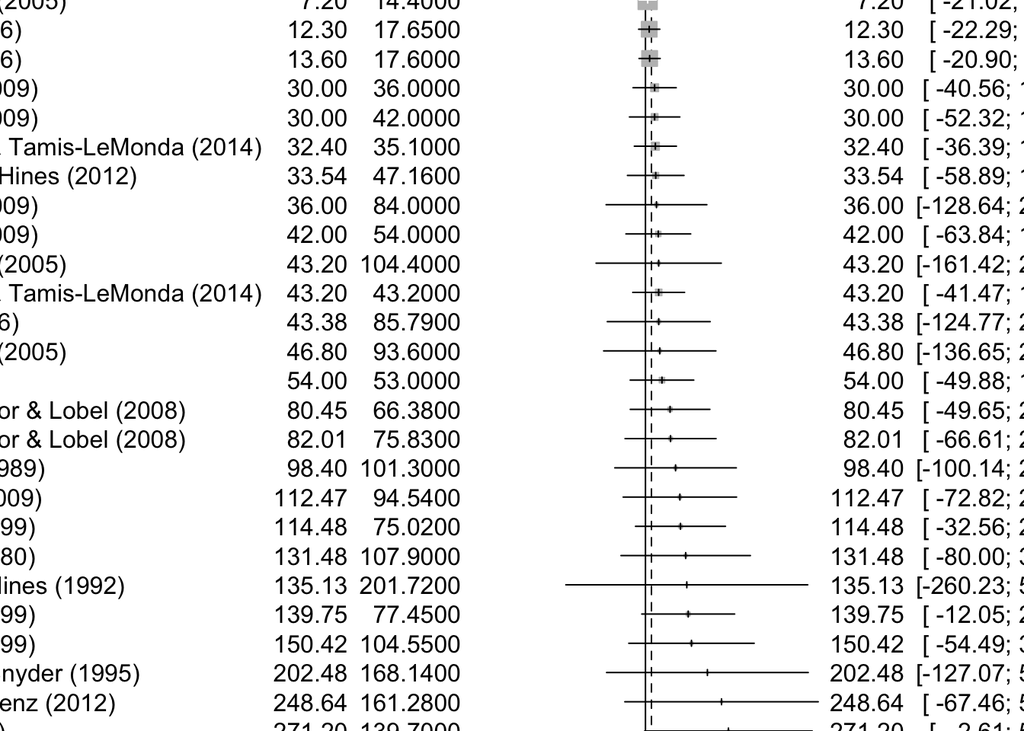

```r
girls_male_FE %>% forest(sortvar=Mean_girls_play_male)
```

Next we analyze Forest graph for RE model.

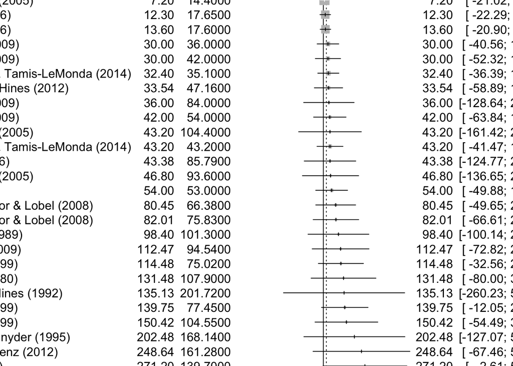

```r
girls_male_RE %>% forest(sortvar=Mean_girls_play_male)
```

> **Comments**

The same results like in Fixed Effect Model.

## Goal: verifying the reliability of the literature

For Fixed Effect Model we use Funnel Plot.

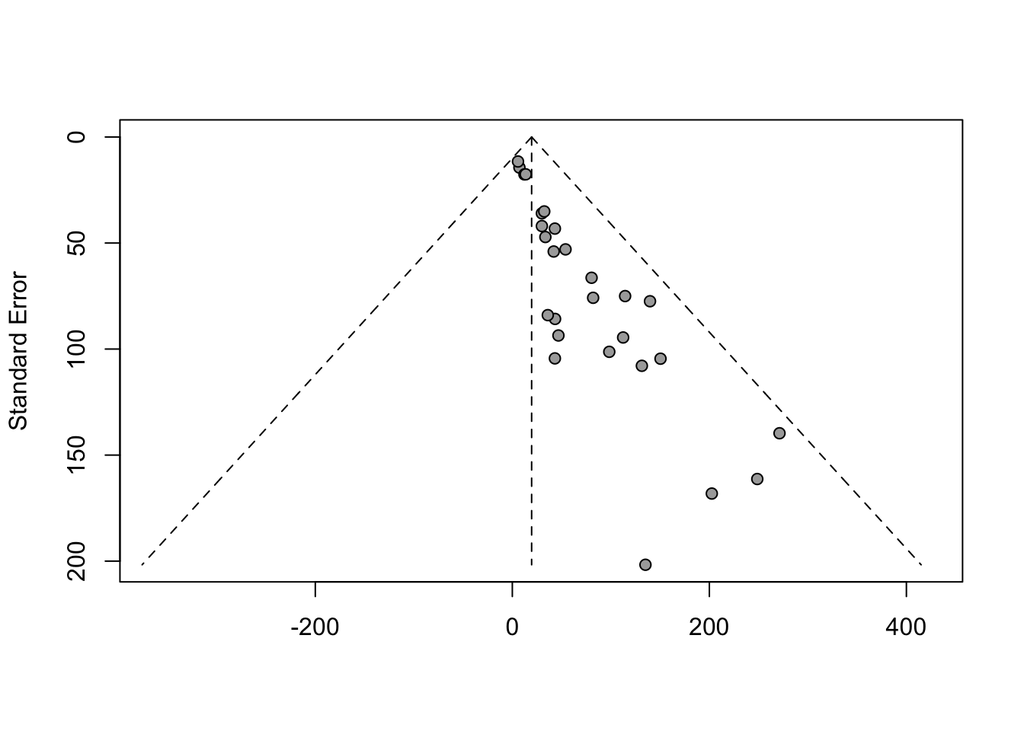

```r
girls_male_FE %>% funnel()
```

> **Comments**
- Based on the Funnel plot we can see that observations from studies behave non-symmetric. So we suspect that exists publication bias.

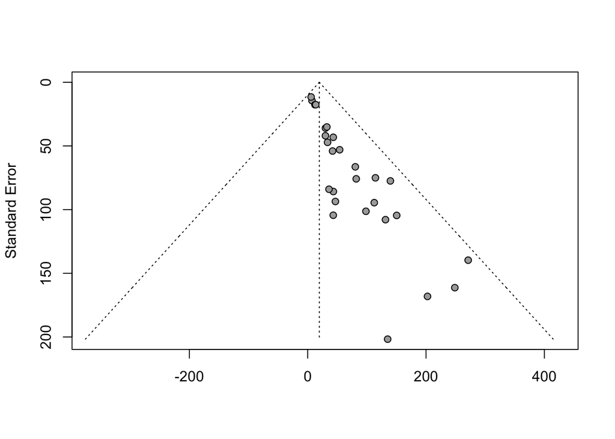

```r
girls_male_RE %>% funnel()
```

The simalar results after RE models.

# Case 2 - Boys play male’s toys

## Goal: finding the true/combined effect size

We start with Fixed Effect Model.

```r
boys_male_FE <- metagen(
            TE=Mean_boys_play_male,
             seTE=SD_boys_play_male,
             data=my_data,
             studlab=paste(Study),
             comb.fixed = TRUE,
             comb.random = FALSE)
boys_male_FE
```

```
## Number of studies combined: k = 27
##
##                                          95%-CI    z  p-value
## Common effect model 96.0551 [71.9496; 120.1605] 7.81 < 0.0001
##
## Quantifying heterogeneity:
##  tau^2 = 5063.4218 [836.1518; 17480.4313]; tau = 71.1577 [28.9163; 132.2136]
##  I^2 = 48.7% [19.8%; 67.2%]; H = 1.40 [1.12; 1.75]
##
## Test of heterogeneity:
##      Q d.f. p-value
##  50.67   26  0.0026
##
## Details on meta-analytical method:
## - Inverse variance method
## - Restricted maximum-likelihood estimator for tau^2
## - Q-profile method for confidence interval of tau^2 and tau
```

> **Comments**
- Common effect model is significant and equal to 96.0551.
- Based on Test of heterogeneity we reject H0.

Next we use Random Effects Model.

```r
boys_male_RE <- metagen(
             TE=Mean_boys_play_male,
             seTE=SD_boys_play_male,
             data=my_data,
             studlab=paste(Study),
             comb.fixed = FALSE,
             comb.random = TRUE)
boys_male_RE
```

```
## Number of studies combined: k = 27
##
##                                            95%-CI    z  p-value
## Random effects model 138.2605 [95.9332; 180.5879] 6.40 < 0.0001
##
## Quantifying heterogeneity:
##  tau^2 = 5063.4218 [836.1518; 17480.4313]; tau = 71.1577 [28.9163; 132.2136]
##  I^2 = 48.7% [19.8%; 67.2%]; H = 1.40 [1.12; 1.75]
##
## Test of heterogeneity:
##      Q d.f. p-value
##  50.67   26  0.0026
##
## Details on meta-analytical method:
## - Inverse variance method
## - Restricted maximum-likelihood estimator for tau^2
## - Q-profile method for confidence interval of tau^2 and tau
```

> **Comments**
- Random effects model is significant and equal to 138.2605.
- Based on Test of heterogeneity we reject H0.

Next we analyze Forest graph for FE model.

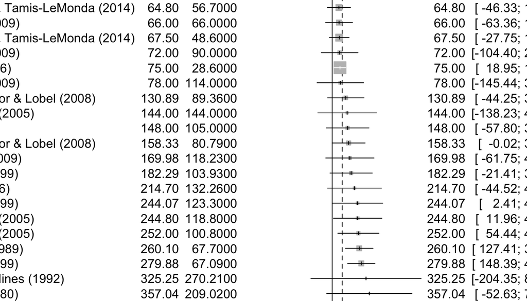

```r
boys_male_FE %>% forest(sortvar=Mean_boys_play_male)
```

> **Comments**
- In the case 2, we can see that in most studies there is some consistency in the reported effect size.

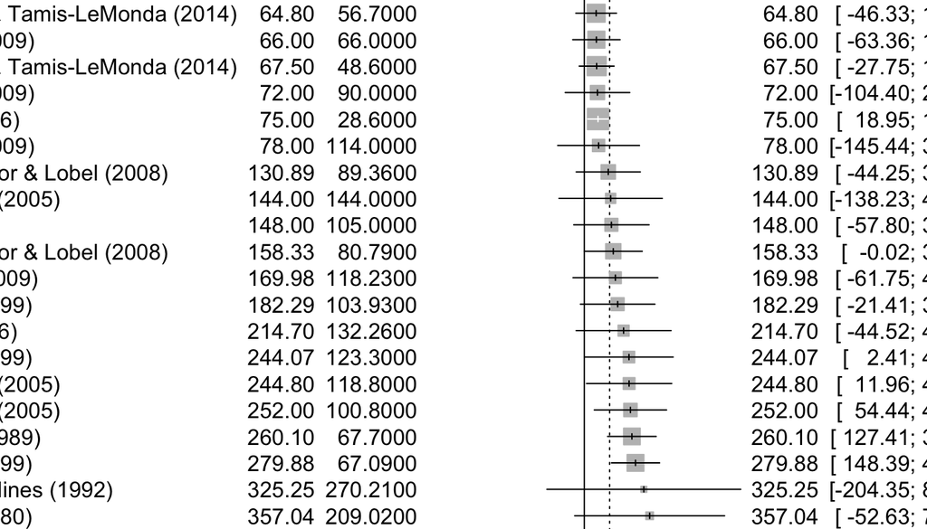

```r
boys_male_RE %>% forest(sortvar=Mean_boys_play_male)
```

## Goal: verifying the reliability of the literature (Checking for publication bias)

For Fixed Effect Model we use Funnel Plot.

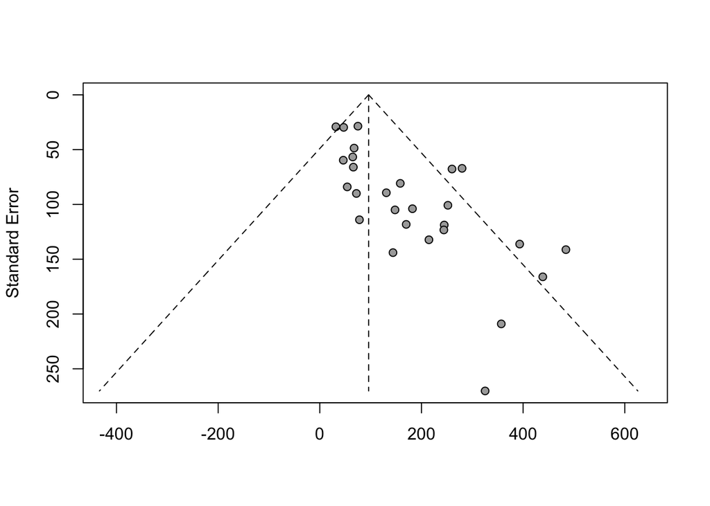

```r
boys_male_FE %>% funnel()
```

> **Comments**
- Based on the Funnel plot we can see that observations from studies behave non-symmetric. So we suspect that exists publication bias.

```r
boys_male_RE %>% funnel()
```

[output not shown]

# Case 3 - Boys play female’s toys

## Goal: finding the true/combined effect size

We start with Fixed Effect Model.

```r
boys_female_FE <- metagen(
             TE=Mean_boys_play_female,
             seTE=SD_boys_play_female,
             data=my_data,
             studlab=paste(Study),
             comb.fixed = TRUE,
             comb.random = FALSE)
boys_male_FE
```

[output not shown]

Next we use Random Effects Model.

```r
boys_female_RE <- metagen(
             TE=Mean_boys_play_female,
             seTE=SD_boys_play_female,
             data=my_data,
             studlab=paste(Study),
             comb.fixed = FALSE,
             comb.random = TRUE)
boys_female_RE
```

```
## Number of studies combined: k = 27
##
##                                         95%-CI    z p-value
## Random effects model 17.2890 [5.0517; 29.5262] 2.77  0.0056
##
## Quantifying heterogeneity:
##  tau^2 = 37.5704 [0.0000; >375.7043]; tau = 6.1295 [0.0000; >19.3831]
##  I^2 = 0.0% [0.0%; 42.5%]; H = 1.00 [1.00; 1.32]
##
## Test of heterogeneity:
##      Q d.f. p-value
##  22.06   26  0.6854
##
## Details on meta-analytical method:
## - Inverse variance method
## - Restricted maximum-likelihood estimator for tau^2
## - Q-profile method for confidence interval of tau^2 and tau
```

> **Comments**
- Random effects model is significant and equal to 17.2890.
- Based on Test of heterogeneity there is no grounds to reject H0.

Next we analyze Forest graph for FE model.

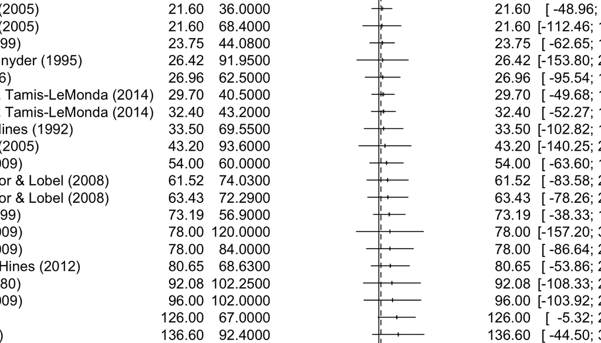

```r
boys_female_FE %>% forest(sortvar=Mean_boys_play_female)
```

> **Comments**
- In the case 3, we can see that in minority studies there is some consistency in the reported effect size.

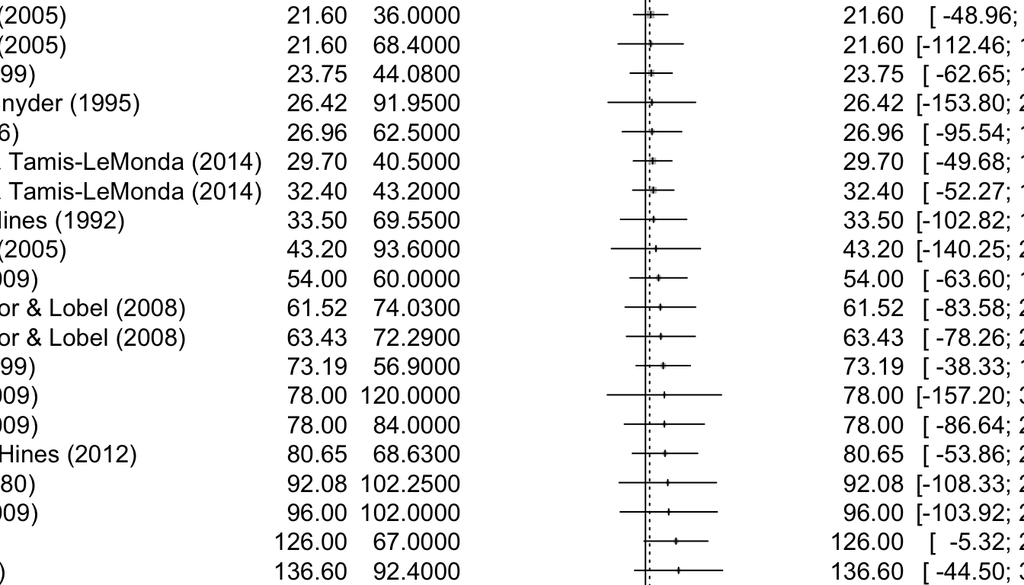

```r
boys_female_RE %>% forest(sortvar=Mean_boys_play_female)
```

> **Comments**
- The same results like in Fixed Effect Model.

## Goal: verifying the reliability of the literature (Checking for publication bias)

```r
boys_male_RE %>% funnel()
```

[output not shown]

```r
boys_male_RE %>% funnel()
```

[output not shown]